# Implicancia de Tenacibaculosis en la mortalidad en Salmón del Atlántico

Constanza Pino Ajenjo

2022-06-02

**Descripción del problema a resolver:** Tenacibaculosis es una infección bacteriana cuya etiología Tenacibaculum maritimus (Flexibacter maritimus) afecta principalmente al cultivo de Salmón del Atlántico. Principalmente se evidencian lesiones macroscópicas en la superficie del cuerpo; úlceras, necrosis, boca erosionada, aletas deshilachadas y cola con pudrición, y a veces necrosis en las branquias y los ojos (congestión choroidal y hemorragia sub-choroidal, a veces con ruptura del ojo). Debido a su impacto en la salud de Salmón del Atlántico, es importante analizar la influencia de esta enfermedad en la mortalidad en los centros de cultivo en agua de mar.

**Variables de estudio:** En este trabajo se observarán las variables obtenidas durante los últimos cinco años en cuanto a número de ingreso de peces a cada centro de cultivo en agua de mar, peso promedio de los peces cosechados en kilogramos (Peso_cosecha), número de mortalidad total (Mortalidad) y número de mortalidad causada por Tenacibaculosis (Mort_Tena), número de mortalidad por Enfermedad Bacteriana del Riñón (Mort_BKD) y número de mortalidad por Septicemia Rickettsial Salmonídea (Mort_SRS).

**Factor a analizar:** Los factores serán las variables Unidad en agua de mar (Unidad) y tipo de alimento (Alimento).

**Número total de observaciones:** Analizaré los resultados observados en 236 unidades o jaulas de cultivo en agua de mar.

```r
#Cargar la base de datos en el objeto Tena:
Tena <- read_excel("Tenacibaculosis.xlsx", sheet=1,na="NA")
Tena <- na.omit(Tena)
head(Tena)
```

```
## # A tibble: 6 × 11
##   Unidad Generación `ID Centro`    `Unidad origen` Alimento Ingreso Peso_cosecha
##    <dbl>      <dbl> <chr>          <chr>           <chr>      <dbl>        <dbl>
## 1      1       2019 SW05 - Linguar 01              BES1       83334          5.3
## 2      2       2019 SW05 - Linguar 02              BES1       83044          4.9
## 3      3       2019 SW05 - Linguar 03              BES1       83333          5.3
## 4      4       2019 SW05 - Linguar 04              BES1       83622          5
## 5      5       2019 SW05 - Linguar 05              BES1       83334          5.7
## 6      6       2019 SW05 - Linguar 06              BES1       83150          5.2
## # … with 4 more variables: Mortalidad <dbl>, Mort_Tena <dbl>, Mort_BKD <dbl>,
## #   Mort_SRS <dbl>
```

```r
#Ordenar Tena creando un objeto tidy_Tena con las variables de interés:
tidy_Tena <- select(Tena,Unidad,Alimento,Ingreso,Peso_cosecha,Mortalidad,Mort_Tena,Mort_BKD,Mort_SRS)
head(tidy_Tena)
```

```
## # A tibble: 6 × 8
##   Unidad Alimento Ingreso Peso_cosecha Mortalidad Mort_Tena Mort_BKD Mort_SRS
##    <dbl> <chr>      <dbl>        <dbl>      <dbl>     <dbl>    <dbl>    <dbl>
## 1      1 BES1       83334          5.3       6748         0      816      254
## 2      2 BES1       83044          4.9       5850         0       39      331
## 3      3 BES1       83333          5.3       8116        11      157      430
## 4      4 BES1       83622          5         4632         7       31      275
## 5      5 BES1       83334          5.7      12765        64       20     1195
## 6      6 BES1       83150          5.2      10187        92       24     1168
```

```r
#Explorar si las variables son números o carácteres:
str(tidy_Tena)
```

```
## tibble [236 × 8] (S3: tbl_df/tbl/data.frame)
##  $ Unidad      : num [1:236] 1 2 3 4 5 6 7 8 9 10 ...
##  $ Alimento    : chr [1:236] "BES1" "BES1" "BES1" "BES1" ...
##  $ Ingreso     : num [1:236] 83334 83044 83333 83622 83334 ...
##  $ Peso_cosecha: num [1:236] 5.3 4.9 5.3 5 5.7 5.2 4.6 5.3 5.4 5.4 ...
##  $ Mortalidad  : num [1:236] 6748 5850 8116 4632 12765 ...
##  $ Mort_Tena   : num [1:236] 0 0 11 7 64 92 0 91 1 84 ...
##  $ Mort_BKD    : num [1:236] 816 39 157 31 20 24 34 18 29 46 ...
##  $ Mort_SRS    : num [1:236] 254 331 430 275 1195 ...
```

```r
#Transformar Unidad y Alimento a factor usando as.factor, luego visualizar que Unidad y Alimento estén transformados adecuadamente a factor y que los datos están balanceados:
tidy_Tena$Unidad <- as.factor(tidy_Tena$Unidad)
tidy_Tena$Alimento <- as.factor(tidy_Tena$Alimento)
summary(tidy_Tena)
```

```
##      Unidad      Alimento      Ingreso        Peso_cosecha     Mortalidad
##  1      :  1   BES1  : 83   Min.   : 50000   Min.   :0.000   Min.   :  449
##  2      :  1   BES1S2: 17   1st Qu.: 78572   1st Qu.:0.000   1st Qu.: 8532
##  3      :  1   BS1   :118   Median : 85000   Median :4.900   Median :13488
##  4      :  1   BS1S2 : 14   Mean   : 85703   Mean   :3.777   Mean   :14629
##  5      :  1   ES1S2 :  4   3rd Qu.: 96211   3rd Qu.:5.500   3rd Qu.:18856
##  6      :  1                Max.   :138228   Max.   :6.300   Max.   :48484
##  (Other):230
##    Mort_Tena          Mort_BKD         Mort_SRS
##  Min.   :    0.0   Min.   :  14.0   Min.   :    0.0
##  1st Qu.:    1.0   1st Qu.:  62.0   1st Qu.:  366.5
##  Median :  130.5   Median : 140.0   Median : 1662.0
##  Mean   :  713.3   Mean   : 469.0   Mean   : 2437.1
##  3rd Qu.:  648.2   3rd Qu.: 409.2   3rd Qu.: 3698.5
##  Max.   :10189.0   Max.   :5448.0   Max.   :16757.0
##
```

```r
table(tidy_Tena$Unidad,tidy_Tena$Alimento)
```

[output not shown]

[output cut: 223 more lines]

**Tablas de resumen:** En la tabla 1 se muestra la base de datos que se utiliza en este trabajo y, luego, en la tabla 2 está un resumen de estadística descriptiva.

```r
#Generar una tabla con la base de datos de tidy_Tena con función datatable:
DT::datatable(tidy_Tena,caption="Tabla 1. Número de peces ingresados, peso cosecha, mortalidad total, mortalidad Tenacibaculosis, mortalidad BKD y mortalidad SRS por Unidad")
```

|  | Unidad | Alimento | Ingreso | Peso_cosecha | Mortalidad | Mort_Tena | Mort_BKD | Mort_SRS |
| --- | --- | --- | --- | --- | --- | --- | --- | --- |
| 1 | 1 | BES1 | 83334 | 5.3 | 6748 | 0 | 816 | 254 |
| 2 | 2 | BES1 | 83044 | 4.9 | 5850 | 0 | 39 | 331 |
| 3 | 3 | BES1 | 83333 | 5.3 | 8116 | 11 | 157 | 430 |
| 4 | 4 | BES1 | 83622 | 5 | 4632 | 7 | 31 | 275 |
| 5 | 5 | BES1 | 83334 | 5.7 | 12765 | 64 | 20 | 1195 |
| 6 | 6 | BES1 | 83150 | 5.2 | 10187 | 92 | 24 | 1168 |
| 7 | 7 | BES1 | 83333 | 4.6 | 7896 | 0 | 34 | 293 |
| 8 | 8 | BES1 | 83516 | 5.3 | 8721 | 91 | 18 | 1246 |
| 9 | 9 | BES1 | 83334 | 5.4 | 7434 | 1 | 29 | 393 |
| 10 | 10 | BES1 | 82300 | 5.4 | 8876 | 84 | 46 | 1081 |

[output cut: 226 more lines]

```r
#Resumen de estadística descriptiva con función pander:
pander(summary(tidy_Tena,caption="Tabla 2. Resumen data frame"))
```

Table continues below

| Unidad | Alimento | Ingreso | Peso_cosecha | Mortalidad |
| --- | --- | --- | --- | --- |
| 1 : 1 | BES1 : 83 | Min. : 50000 | Min. :0.000 | Min. : 449 |
| 2 : 1 | BES1S2: 17 | 1st Qu.: 78572 | 1st Qu.:0.000 | 1st Qu.: 8532 |
| 3 : 1 | BS1 :118 | Median : 85000 | Median :4.900 | Median :13488 |
| 4 : 1 | BS1S2 : 14 | Mean : 85703 | Mean :3.777 | Mean :14629 |
| 5 : 1 | ES1S2 : 4 | 3rd Qu.: 96211 | 3rd Qu.:5.500 | 3rd Qu.:18856 |
| 6 : 1 | NA | Max. :138228 | Max. :6.300 | Max. :48484 |
| (Other):230 | NA | NA | NA | NA |

| Mort_Tena | Mort_BKD | Mort_SRS |
| --- | --- | --- |
| Min. : 0.0 | Min. : 14.0 | Min. : 0.0 |
| 1st Qu.: 1.0 | 1st Qu.: 62.0 | 1st Qu.: 366.5 |
| Median : 130.5 | Median : 140.0 | Median : 1662.0 |
| Mean : 713.3 | Mean : 469.0 | Mean : 2437.1 |
| 3rd Qu.: 648.2 | 3rd Qu.: 409.2 | 3rd Qu.: 3698.5 |
| Max. :10189.0 | Max. :5448.0 | Max. :16757.0 |
| NA | NA | NA |

**Gráficos de histogramas y boxplot:** Se describe la variación de cada variable de estudio usando histogramas y boxplot. En la Figura 1 se muestran los histogramas de ingreso, peso cosecha, mortalidad total, mortalidad por Tenacibaculosis, mortalidad por BKD y mortalidad por SRS. Mientras que en la Figura 2 y 3 se muestran los boxplot de las mismas variables por Unidad y tipo de alimento respectivamente.

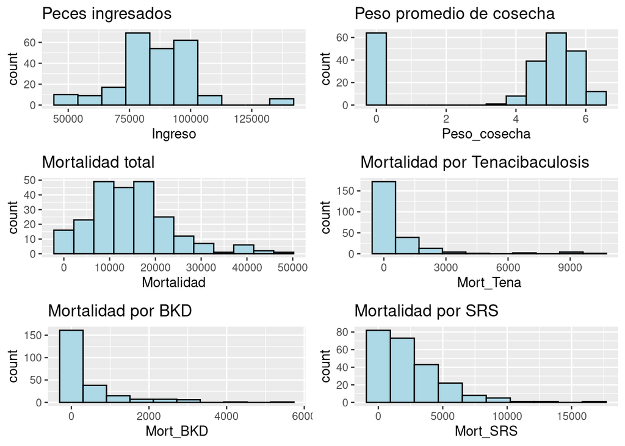

```r
#Observar el comportamiento de las variables en estudio usando histogramas y boxplot (valor atípico se muestra en punto de color rojo):

hist_ing <- ggplot(tidy_Tena,aes(Ingreso))+
  geom_histogram(fill="lightblue",color="black",bins=10)+
  labs(title = "Peces ingresados")

hist_peso <- ggplot(tidy_Tena,aes(Peso_cosecha))+
  geom_histogram(fill="lightblue",color="black",bins=12)+
  labs(title = "Peso promedio de cosecha")

hist_mort <- ggplot(tidy_Tena,aes(Mortalidad))+
  geom_histogram(fill="lightblue",color="black",bins=12)+
  labs(title = "Mortalidad total")

hist_Tena <- ggplot(tidy_Tena,aes(Mort_Tena))+
  geom_histogram(fill="lightblue",color="black",bins=10)+
  labs(title = "Mortalidad por Tenacibaculosis")

hist_BKD <- ggplot(tidy_Tena,aes(Mort_BKD))+
  geom_histogram(fill="lightblue",color="black",bins=10)+
  labs(title = "Mortalidad por BKD")

hist_SRS <- ggplot(tidy_Tena,aes(Mort_SRS))+
  geom_histogram(fill="lightblue",color="black",bins=10)+
  labs(title = "Mortalidad por SRS")

grid.arrange(hist_ing, hist_peso, hist_mort, hist_Tena, hist_BKD, hist_SRS, ncol=2, nrow =3)
```

Figura 1.

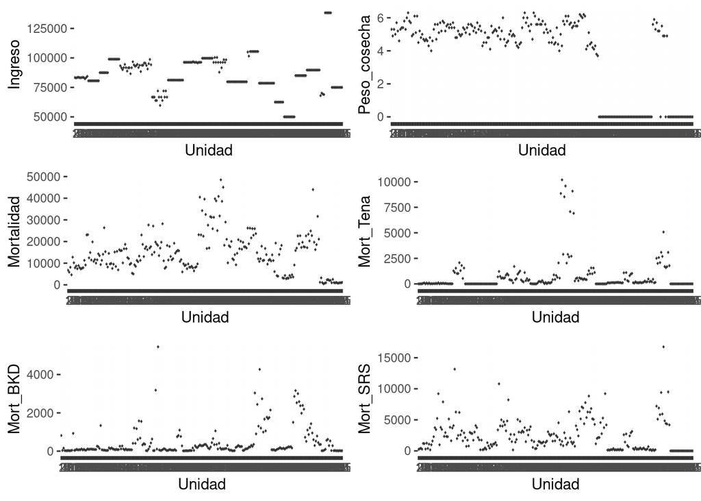

```r
bi <-ggplot(data=tidy_Tena, aes(x=Unidad,y=Ingreso))+geom_boxplot()
bp <-ggplot(data=tidy_Tena, aes(x=Unidad,y=Peso_cosecha))+geom_boxplot()
bm <-ggplot(data=tidy_Tena, aes(x=Unidad,y=Mortalidad))+geom_boxplot()
bt <-ggplot(data=tidy_Tena, aes(x=Unidad,y=Mort_Tena))+geom_boxplot()
bb <-ggplot(data=tidy_Tena, aes(x=Unidad,y=Mort_BKD))+geom_boxplot()
bs <-ggplot(data=tidy_Tena, aes(x=Unidad,y=Mort_SRS))+geom_boxplot()

grid.arrange(bi, bp, bm, bt, bb, bs, ncol=2, nrow =3)
```

Figura 2.

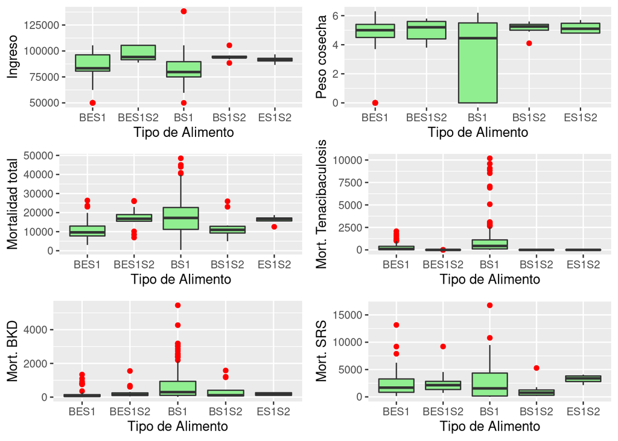

```r
blot_ing <- ggplot(tidy_Tena,aes(y=Ingreso,x=Alimento))+
  geom_boxplot(fill="lightgreen",outlier.colour = "red")+
  labs(y="Ingreso",x="Tipo de Alimento")

blot_peso <- ggplot(tidy_Tena,aes(y=Peso_cosecha,x=Alimento))+
  geom_boxplot(fill="lightgreen",outlier.colour = "red")+
  labs(y="Peso cosecha",x="Tipo de Alimento")

blot_mort <- ggplot(tidy_Tena,aes(y=Mortalidad,x=Alimento))+
  geom_boxplot(fill="lightgreen",outlier.colour = "red")+
  labs(y="Mortalidad total",x="Tipo de Alimento")

blot_Tena <- ggplot(tidy_Tena,aes(y=Mort_Tena,x=Alimento))+
  geom_boxplot(fill="lightgreen",outlier.colour = "red")+
  labs(y="Mort. Tenacibaculosis",x="Tipo de Alimento")

blot_BKD <- ggplot(tidy_Tena,aes(y=Mort_BKD,x=Alimento))+
  geom_boxplot(fill="lightgreen",outlier.colour = "red")+
  labs(y="Mort. BKD",x="Tipo de Alimento")

blot_SRS <- ggplot(tidy_Tena,aes(y=Mort_SRS,x=Alimento))+
  geom_boxplot(fill="lightgreen",outlier.colour = "red")+
  labs(y="Mort. SRS",x="Tipo de Alimento")

grid.arrange(blot_ing, blot_peso, blot_mort, blot_Tena, blot_BKD, blot_SRS, ncol=2, nrow =3)
```

Figura 3.

**Gráficos de interacción:** En las siguientes figuras se muestran los gráficos de interacción entre cada variable cuantitativa y los factores Unidad y Alimento.

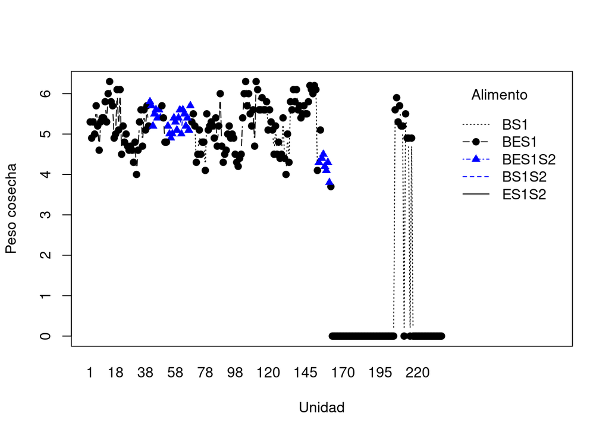

```r
#Establecer relación entre variables cuantitativas y factores usando gráficas de correlación, boxplot, interacción o de tamaño de los efectos:

ip1 <- interaction.plot(tidy_Tena$Unidad,tidy_Tena$Alimento, tidy_Tena$Peso_cosecha,trace.label="Alimento",fun=mean, xlab="Unidad",ylab="Peso cosecha",type="b", col= c("black", "blue"),pch=c(19,17))
```

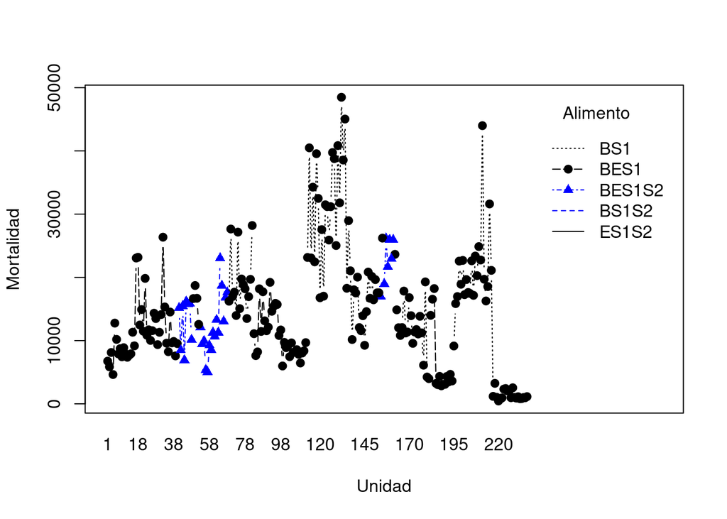

```r
ip2 <- interaction.plot(tidy_Tena$Unidad,tidy_Tena$Alimento, tidy_Tena$Mortalidad,trace.label="Alimento",fun=mean,xlab="Unidad",ylab="Mortalidad",type="b", col= c("black", "blue"),pch=c(19,17))
```

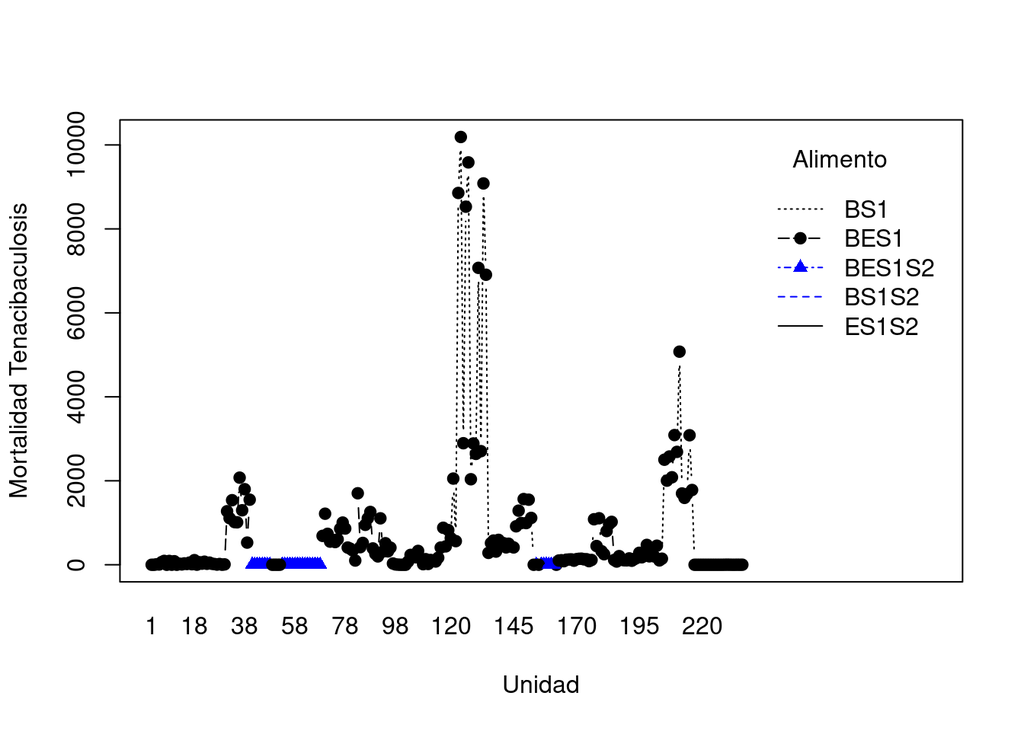

```r
ip3 <- interaction.plot(tidy_Tena$Unidad,tidy_Tena$Alimento, tidy_Tena$Mort_Tena,trace.label="Alimento",fun=mean,xlab="Unidad",ylab="Mortalidad Tenacibaculosis",type="b", col= c("black", "blue"),pch=c(19,17))
```

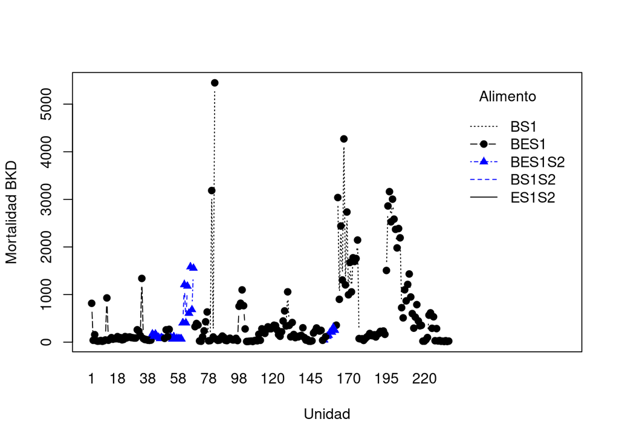

```r
ip4 <- interaction.plot(tidy_Tena$Unidad,tidy_Tena$Alimento, tidy_Tena$Mort_BKD,trace.label="Alimento",fun=mean,xlab="Unidad",ylab="Mortalidad BKD",type="b", col= c("black", "blue"),pch=c(19,17))
```

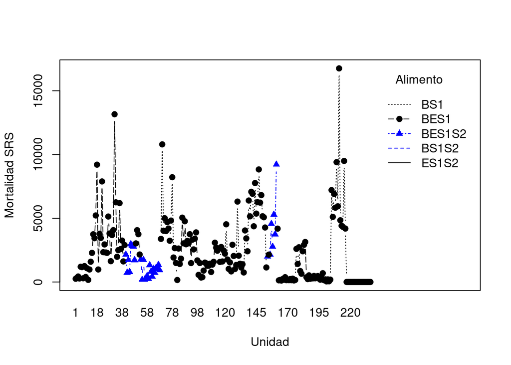

```r
ip5 <- interaction.plot(tidy_Tena$Unidad,tidy_Tena$Alimento, tidy_Tena$Mort_SRS,trace.label="Alimento",fun=mean,xlab="Unidad",ylab="Mortalidad SRS",type="b", col= c("black", "blue"),pch=c(19,17))
```

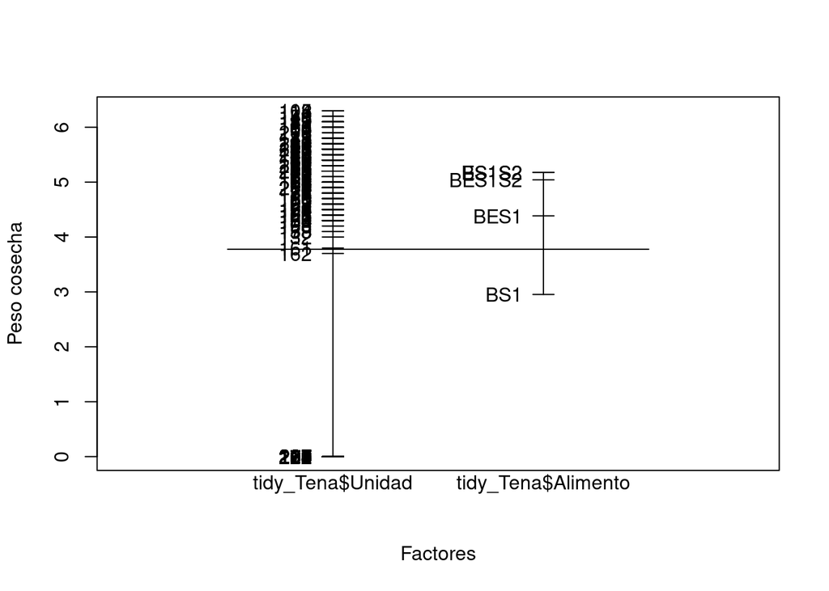

```r
id1 <- plot.design(tidy_Tena$Peso_cosecha~tidy_Tena$Unidad*tidy_Tena$Alimento,xlab="Factores", ylab="Peso cosecha")
```

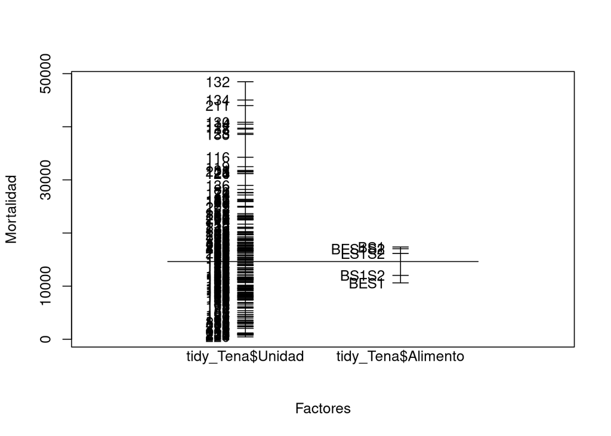

```r
id2 <- plot.design(tidy_Tena$Mortalidad~tidy_Tena$Unidad*tidy_Tena$Alimento,xlab="Factores", ylab="Mortalidad")
```

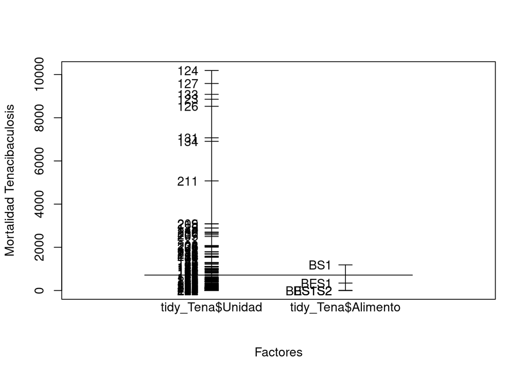

```r
id3 <- plot.design(tidy_Tena$Mort_Tena~tidy_Tena$Unidad*tidy_Tena$Alimento,xlab="Factores", ylab="Mortalidad Tenacibaculosis")
```

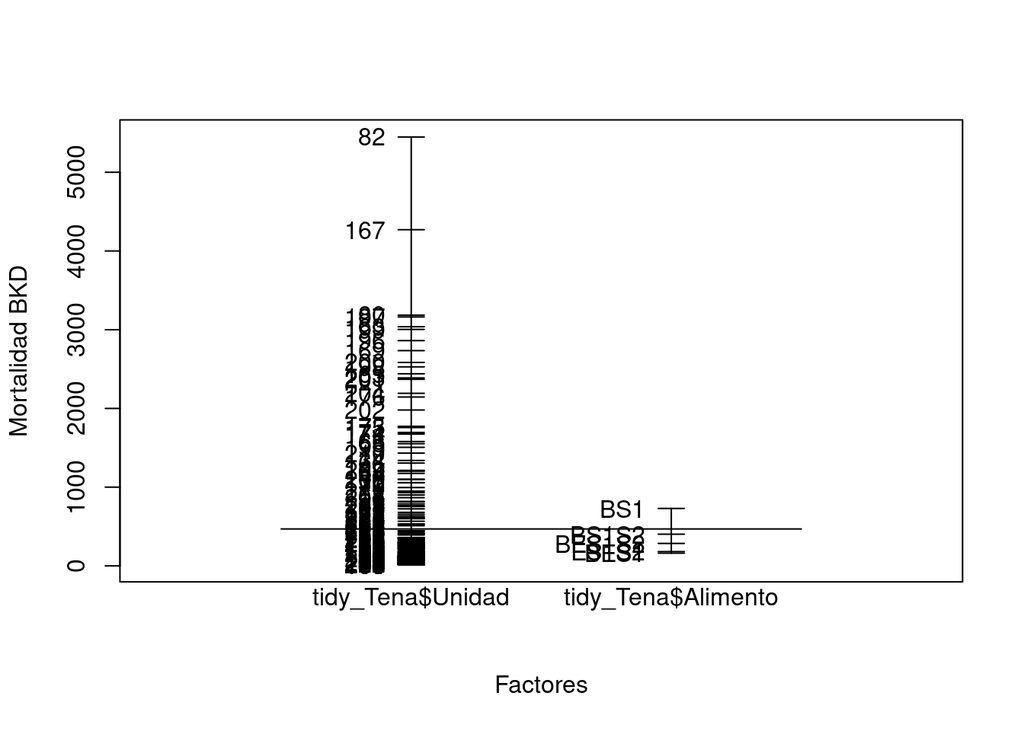

```r
id4 <- plot.design(tidy_Tena$Mort_BKD~tidy_Tena$Unidad*tidy_Tena$Alimento,xlab="Factores", ylab="Mortalidad BKD")
```

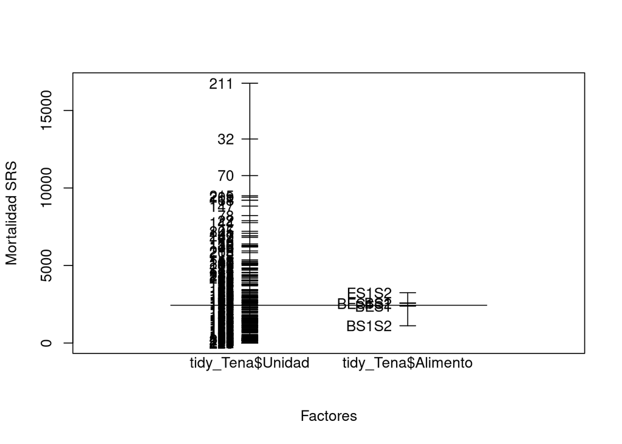

```r
id5 <- plot.design(tidy_Tena$Mort_SRS~tidy_Tena$Unidad*tidy_Tena$Alimento,xlab="Factores", ylab="Mortalidad SRS")
```